# growth models eval

#### Combined sample sizes for growth

```r
rbind(t_samp_year_webl$`_data`,t_samp_year_tres$`_data`) %>% dplyr::select(Habitat, `2021`, `2022`, `2023`) %>%
  mutate(Species = c(rep("WEBL",4),rep("TRES",4)),
         Response = "Growth") %>%
  # mutate(row=row_number()) %>%
  group_by(Response) %>%
  pivot_longer(-c(Species, Response, Habitat)) %>%
  pivot_wider(names_from=c(Species, name), values_from=value) %>%
  # dplyr::select(-row) %>%
  gt() %>% tab_options(data_row.padding = px(1)) %>%
  tab_spanner_delim(
    delim="_")
```

| Habitat | WEBL 2021 | WEBL 2022 | WEBL 2023 | TRES 2021 | TRES 2022 | TRES 2023 |
| --- | --- | --- | --- | --- | --- | --- |
| Growth |  |  |  |  |  |  |
| Forest | 31 | 47 | 29 | 7 | 14 | 18 |
| Orchard | 40 | 77 | 22 | 9 | 10 | 11 |
| Grassland | 25 | 37 | 33 | 73 | 85 | 23 |
| Row crop | 31 | 38 | 28 | 33 | 38 | 26 |

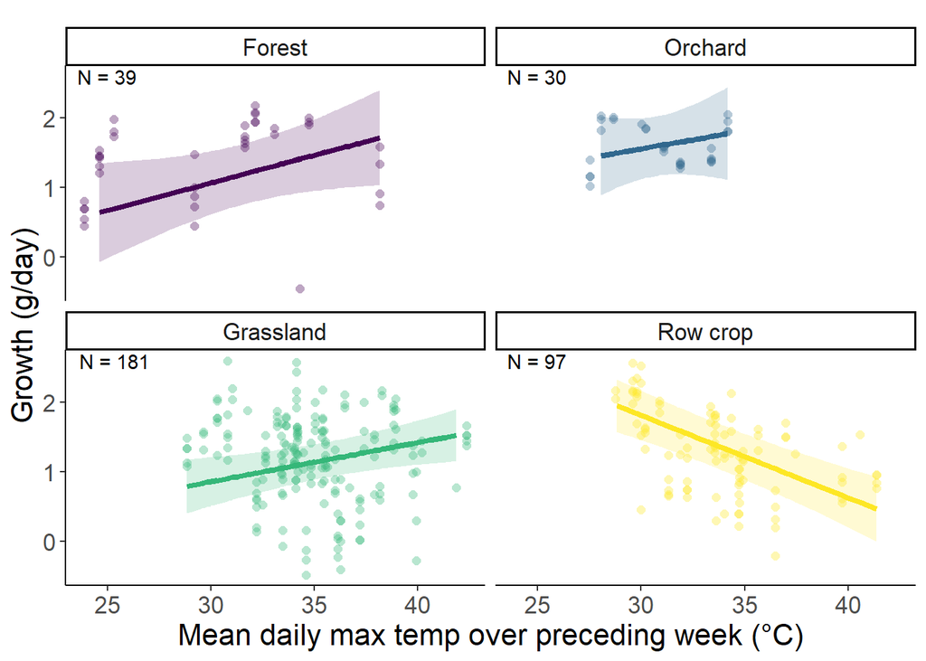

```r
data_tres = dplyr::filter(g,Species == "TRES",!is.na(meanmaxtempI),meanmaxtempI < 45,!is.na(meanmintempI)) %>%
  mutate(across(c(gweight,meanmaxtempI,meanmintempI,juliandate,brood_size,age),
                                                  ~ scale(.x)[,1],
                                                   .names = "{.col}_scaled"),
                                           meanmaxtempI_scaled_sq = meanmaxtempI_scaled * meanmaxtempI_scaled)


mean_temp_tres <- mean(data_tres %>% pull(meanmaxtempI))
sd_temp_tres <- sd(data_tres %>% pull(meanmaxtempI))


temp_trans_tres <- trans_new("temp_trans",
                          transform = function(x){(x * sd_temp_tres) + mean_temp_tres},
                          inverse = function(x){x})

(fig2_tres <- ggpredict(g_lintemp_addmin,terms = c("meanmaxtempI_scaled [all]","habitat"),bias_correction = TRUE) %>%
   plot(line_size = 1.5,alpha = .2,show_data = TRUE,limit_range = TRUE) +
    theme_classic() +
   facet_wrap(~ group, ncol = 2) +
    xlab("Mean daily max temp over preceding week (\u00b0C)") +
    ylab("Growth (g/day)") +
   scale_fill_viridis(discrete = TRUE) +
    scale_color_viridis(discrete = TRUE) +
    theme(text = element_text(size = 16)) +
    labs(title = element_blank()) +
    scale_x_continuous(trans = temp_trans_tres,
                       breaks = c((20-mean_temp_tres)/sd_temp_tres,
                                  (25-mean_temp_tres)/sd_temp_tres,
                                  (30-mean_temp_tres)/sd_temp_tres,
                                  (35-mean_temp_tres)/sd_temp_tres,
                                  (40-mean_temp_tres)/sd_temp_tres),
                       # breaks = c(20,30,40,50),
                       # labels = c("20","30","40","50"),
                       # limits = c((15-mean(g$meanmaxtempI,na.rm = TRUE))/sd(g$meanmaxtempI,na.rm = TRUE),
                       #            (55-mean(g$meanmaxtempI,na.rm = TRUE))/sd(g$meanmaxtempI,na.rm = TRUE))
                       # limits = c(18,5)
                       ) +
   #ylim(-5,5) +
   geom_text(data = dat_text_tres, mapping = aes(x = -Inf, y = Inf,label = label),hjust = -.2, vjust = 1.2,inherit.aes = FALSE) +
    theme(legend.position = "none")
   )
```

```r
ggsave("../figures/growthbytempxhab_TRES.png",plot =  fig2_tres, width = 10, height = 6.6)
```

```r
summary(g_lintemp_addmin)
```

```
## Linear mixed model fit by REML. t-tests use Satterthwaite's method [
## lmerModLmerTest]
## Formula: gweight ~ meanmaxtempI_scaled * habitat + meanmintempI_scaled +
##     age_scaled + juliandate_scaled + year_fct + (1 | attempt_id)
##    Data:
## dplyr::filter(g, Species == "TRES", !is.na(meanmaxtempI), meanmaxtempI <
##     45, !is.na(meanmintempI)) %>% mutate(across(c(gweight, meanmaxtempI,
##     meanmintempI, juliandate, brood_size, age), ~scale(.x)[,
##     1], .names = "{.col}_scaled"), meanmaxtempI_scaled_sq = meanmaxtempI_scaled *
##     meanmaxtempI_scaled)
##
## REML criterion at convergence: 481.2
##
## Scaled residuals:
##     Min      1Q  Median      3Q     Max
## -2.9112 -0.4837  0.0453  0.5235  2.9293
##
## Random effects:
##  Groups     Name        Variance Std.Dev.
##  attempt_id (Intercept) 0.2506   0.5006
##  Residual               0.1465   0.3827
## Number of obs: 347, groups:  attempt_id, 66
##
## Fixed effects:
##                                       Estimate Std. Error        df t value
## (Intercept)                            1.36364    0.23743  49.47628   5.743
## meanmaxtempI_scaled                    0.28925    0.14873  68.64474   1.945
## habitatOrchard                         0.38732    0.36471  62.36341   1.062
## habitatGrassland                      -0.29218    0.24946  52.65626  -1.171
## habitatRow crop                        0.01342    0.25030  49.65483   0.054
## meanmintempI_scaled                   -0.06714    0.08278  69.72213  -0.811
## age_scaled                            -0.18973    0.03604 279.46290  -5.264
## juliandate_scaled                     -0.12423    0.07609  55.13975  -1.633
## year_fct2022                           0.04769    0.15803  45.63432   0.302
## year_fct2023                           0.32994    0.18927  46.41092   1.743
## meanmaxtempI_scaled:habitatOrchard    -0.10132    0.31018  97.39173  -0.327
## meanmaxtempI_scaled:habitatGrassland  -0.08425    0.15241  88.69503  -0.553
## meanmaxtempI_scaled:habitatRow crop   -0.72126    0.15880  93.73325  -4.542
##                                      Pr(>|t|)
## (Intercept)                          5.64e-07 ***
## meanmaxtempI_scaled                    0.0559 .
## habitatOrchard                         0.2923
## habitatGrassland                       0.2468
## habitatRow crop                        0.9575
## meanmintempI_scaled                    0.4201
## age_scaled                           2.82e-07 ***
## juliandate_scaled                      0.1082
## year_fct2022                           0.7642
## year_fct2023                           0.0879 .
## meanmaxtempI_scaled:habitatOrchard     0.7446
## meanmaxtempI_scaled:habitatGrassland   0.5818
## meanmaxtempI_scaled:habitatRow crop  1.66e-05 ***
## ---
## Signif. codes:  0 '***' 0.001 '**' 0.01 '*' 0.05 '.' 0.1 ' ' 1
```

```r
(t <- emtrends(g_lintemp_addmin,specs = ~ habitat, var = c("meanmaxtempI_scaled")) %>% test() %>%
   mutate(across(where(is.numeric), ~ round(.x, digits = 3)),
          df = round(df),
          p.value = if_else(p.value == 0.000,"<0.001",as.character(p.value))) %>%
   rename(Habitat = "habitat", `Max temp trend` = "meanmaxtempI_scaled.trend",Df = "df", `T-ratio` = "t.ratio", P = "p.value") %>%
   gt())
```

| Habitat | Max temp trend | SE | Df | T-ratio | P |
| --- | --- | --- | --- | --- | --- |
| Forest | 0.289 | 0.150 | 84 | 1.931 | 0.057 |
| Orchard | 0.188 | 0.270 | 125 | 0.695 | 0.488 |
| Grassland | 0.205 | 0.081 | 281 | 2.534 | 0.012 |
| Row crop | -0.432 | 0.077 | 291 | -5.622 | <0.001 |

```r
gtsave(t,"../figures/tresgrowthtrendmax.html")

data = dplyr::filter(g,Species == "TRES",!is.na(meanmaxtempI),meanmaxtempI < 45,!is.na(meanmintempI)) %>%
  mutate(across(c(gweight,meanmaxtempI,meanmintempI,juliandate,brood_size,age),
                                                  ~ scale(.x)[,1],
                                                   .names = "{.col}_scaled"),
                                           meanmaxtempI_scaled_sq = meanmaxtempI_scaled * meanmaxtempI_scaled)

(t <- emmeans(g_lintemp_addmin,specs = ~ habitat,by = c("meanmaxtempI_scaled"), at = list(meanmaxtempI_scaled = c(-2,0,2)),type = "response") %>% as.tibble() %>% #gt() %>%
  mutate(meanmaxtempI_scaled = (meanmaxtempI_scaled * sd(data$meanmaxtempI)) + mean(data$meanmaxtempI),
    across(where(is.numeric), ~ round(.x, digits = 2)),
    meanmaxtempI_scaled = round(meanmaxtempI_scaled),
    meanmaxtempI_scaled = paste0(meanmaxtempI_scaled,"\u00b0C")) %>%
  #tibble() %>%
  dplyr::select(-df) %>%
  #mutate(Model = rep(c("TA2 * LU + TA * LU", "TA2 + TA * LU", "TA2 + TA + LU"),2), type = c(rep("Maximum TA", 3),rep("Minimum TA",3)), .before = AIC) %>%
  rename(Habitat = "habitat",`Max temperature` = "meanmaxtempI_scaled",`Predicted growth` = "emmean",`2.5%` = "lower.CL",`97.5%` = "upper.CL" ) %>%
  group_by(`Max temperature`) %>%
  mutate(row=row_number()) %>%
  pivot_longer(-c(`Max temperature`, row,Habitat)) %>%
  pivot_wider(names_from=c(`Max temperature`, name), values_from=value) %>%
  dplyr::select(-row) %>%
  #mutate(`Maximum TA_P` = if_else(`Maximum TA_P` == 0.000,"<0.001",as.character(`Maximum TA_P`))) %>%
  #mutate(`Minimum TA_P` = if_else(`Minimum TA_P` == 0.000,"<0.001",as.character(`Minimum TA_P`))) %>%
  gt() %>% tab_options(data_row.padding = px(1)) %>%
  tab_spanner_delim(
    delim="_"
  ))
```

| Habitat | 26°C Predicted growth | 26°C SE | 26°C 2.5% | 26°C 97.5% | 34°C Predicted growth | 34°C SE | 34°C 2.5% | 34°C 97.5% | 41°C Predicted growth | 41°C SE | 41°C 2.5% | 41°C 97.5% |
| --- | --- | --- | --- | --- | --- | --- | --- | --- | --- | --- | --- | --- |
| Forest | 0.91 | 0.27 | 0.37 | 1.46 | 1.49 | 0.22 | 1.05 | 1.93 | 2.07 | 0.45 | 1.17 | 2.96 |
| Orchard | 1.50 | 0.38 | 0.75 | 2.26 | 1.88 | 0.29 | 1.30 | 2.45 | 2.25 | 0.78 | 0.71 | 3.80 |
| Grassland | 0.79 | 0.22 | 0.35 | 1.22 | 1.20 | 0.11 | 0.98 | 1.41 | 1.61 | 0.16 | 1.29 | 1.93 |
| Row crop | 2.37 | 0.19 | 1.99 | 2.75 | 1.50 | 0.13 | 1.24 | 1.77 | 0.64 | 0.21 | 0.22 | 1.06 |

```r
gtsave(t,"../figures/tresgrowthdeltamax.html")

((emmeans(g_lintemp_addmin,specs = ~ habitat,by = c("meanmaxtempI_scaled"), at = list(meanmaxtempI_scaled = c(2)),type = "response") %>% as.tibble() %>% pull(emmean))-(emmeans(g_lintemp_addmin,specs = ~ habitat,by = c("meanmaxtempI_scaled"), at = list(meanmaxtempI_scaled = c(-2)),type = "response") %>% as.tibble() %>% pull(emmean)))/(emmeans(g_lintemp_addmin,specs = ~ habitat,by = c("meanmaxtempI_scaled"), at = list(meanmaxtempI_scaled = c(-2)),type = "response") %>% as.tibble() %>% pull(emmean))
```

```
## [1]  1.2700311  0.5008376  1.0414892 -0.7300650
```

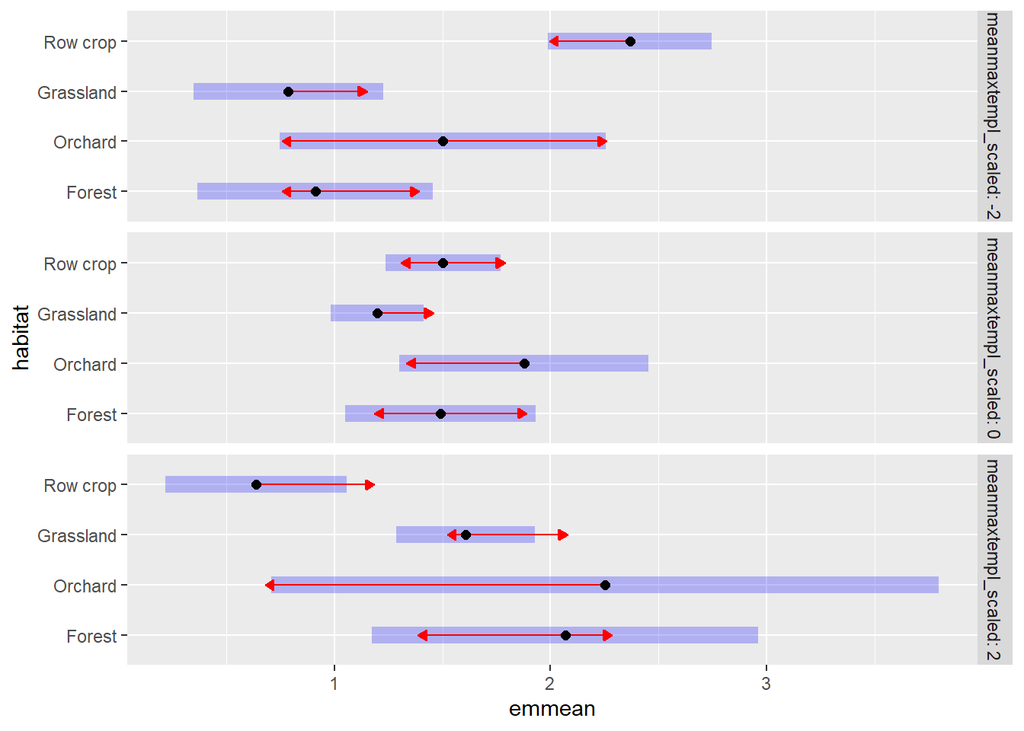

```r
emmeans(g_lintemp_addmin,specs = pairwise ~ habitat,by = c("meanmaxtempI_scaled"), at = list(meanmaxtempI_scaled = c(-2,0,2))) %>% plot(comparisons = TRUE)
```

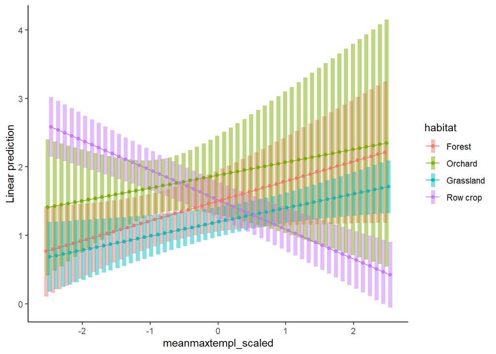

```r
emmip(g_lintemp_addmin,formula = habitat ~ meanmaxtempI_scaled, at = list(meanmaxtempI_scaled = seq(from = -2.5, to = 2.5, by = .1)),CIs = TRUE, plotit = FALSE) %>% emmip_ggplot() + theme_classic()
```

## Emmeans to check for effect of habitat

```r
(t <- emmeans(g_lintemp_addmin,"habitat") %>% regrid() %>% pairs() %>% as_tibble() %>%
   mutate(across(estimate:t.ratio,~round(.x,digits = 2)),
          across(p.value,~round(.x,digits = 3))) %>% gt())
```

| contrast | estimate | SE | df | t.ratio | p.value |
| --- | --- | --- | --- | --- | --- |
| Forest - Orchard | -0.39 | 0.37 | 65.79 | -1.06 | 0.716 |
| Forest - Grassland | 0.29 | 0.25 | 60.33 | 1.17 | 0.648 |
| Forest - Row crop | -0.01 | 0.25 | 54.36 | -0.05 | 1.000 |
| Orchard - Grassland | 0.68 | 0.31 | 60.33 | 2.21 | 0.131 |
| Orchard - Row crop | 0.37 | 0.32 | 54.36 | 1.17 | 0.646 |
| Grassland - Row crop | -0.31 | 0.17 | 54.36 | -1.77 | 0.296 |

```r
gtsave(t,"../figures/growthbyhabitat_tres.html")
```

## min temp

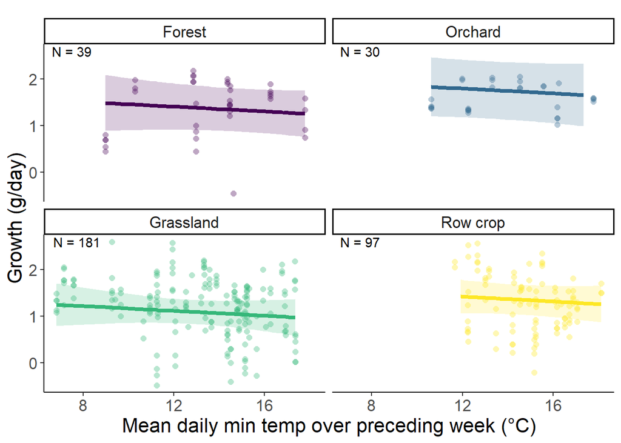

```r
data = dplyr::filter(g,Species == "TRES",!is.na(meanmaxtempI),meanmaxtempI < 45,!is.na(meanmintempI)) %>%
  mutate(across(c(gweight,meanmaxtempI,meanmintempI,juliandate,brood_size,age),
                                                  ~ scale(.x)[,1],
                                                   .names = "{.col}_scaled"),
                                           meanmaxtempI_scaled_sq = meanmaxtempI_scaled * meanmaxtempI_scaled)


mean_temp <- mean(data %>% pull(meanmintempI))
sd_temp <- sd(data %>% pull(meanmintempI))


temp_trans <- trans_new("temp_trans",
                          transform = function(x){(x * sd_temp) + mean_temp},
                          inverse = function(x){x})

(pl <- ggpredict(g_lintemp_addmin,terms = c("meanmintempI_scaled [all]","habitat"),bias_correction = TRUE) %>%
   plot(line_size = 1.5,alpha = .2,show_data = TRUE,limit_range = TRUE) +
    theme_classic() +
   facet_wrap(~ group, ncol = 2) +
    xlab("Mean daily min temp over preceding week (\u00b0C)") +
    ylab("Growth (g/day)") +
   scale_fill_viridis(discrete = TRUE) +
    scale_color_viridis(discrete = TRUE) +
    theme(text = element_text(size = 16)) +
    labs(title = element_blank()) +
    scale_x_continuous(trans = temp_trans,
                       breaks = c((8-mean_temp)/sd_temp,
                                  (12-mean_temp)/sd_temp,
                                  (16-mean_temp)/sd_temp,
                                  (20-mean_temp)/sd_temp),
                       # breaks = c(20,30,40,50),
                       # labels = c("20","30","40","50"),
                       # limits = c((15-mean(g$meanmintempI,na.rm = TRUE))/sd(g$meanmintempI,na.rm = TRUE),
                       #            (55-mean(g$meanmintempI,na.rm = TRUE))/sd(g$meanmintempI,na.rm = TRUE))
                       # limits = c(18,5)
                       ) +
   #ylim(-5,5) +
   geom_text(data = dat_text_tres, mapping = aes(x = -Inf, y = Inf,label = label),hjust = -.2, vjust = 1.2,inherit.aes = FALSE) +
    theme(legend.position = "none")
   )
```

```r
ggsave("../figures/growthbymintempxhab_TRES.png",plot =  pl, width = 10, height = 6.6)
```

```r
summary(g_lintemp_addmin)
```

```
## Linear mixed model fit by REML. t-tests use Satterthwaite's method [
## lmerModLmerTest]
## Formula: gweight ~ meanmaxtempI_scaled * habitat + meanmintempI_scaled +
##     age_scaled + juliandate_scaled + year_fct + (1 | attempt_id)
##    Data:
## dplyr::filter(g, Species == "TRES", !is.na(meanmaxtempI), meanmaxtempI <
##     45, !is.na(meanmintempI)) %>% mutate(across(c(gweight, meanmaxtempI,
##     meanmintempI, juliandate, brood_size, age), ~scale(.x)[,
##     1], .names = "{.col}_scaled"), meanmaxtempI_scaled_sq = meanmaxtempI_scaled *
##     meanmaxtempI_scaled)
##
## REML criterion at convergence: 481.2
##
## Scaled residuals:
##     Min      1Q  Median      3Q     Max
## -2.9112 -0.4837  0.0453  0.5235  2.9293
##
## Random effects:
##  Groups     Name        Variance Std.Dev.
##  attempt_id (Intercept) 0.2506   0.5006
##  Residual               0.1465   0.3827
## Number of obs: 347, groups:  attempt_id, 66
##
## Fixed effects:
##                                       Estimate Std. Error        df t value
## (Intercept)                            1.36364    0.23743  49.47628   5.743
## meanmaxtempI_scaled                    0.28925    0.14873  68.64474   1.945
## habitatOrchard                         0.38732    0.36471  62.36341   1.062
## habitatGrassland                      -0.29218    0.24946  52.65626  -1.171
## habitatRow crop                        0.01342    0.25030  49.65483   0.054
## meanmintempI_scaled                   -0.06714    0.08278  69.72213  -0.811
## age_scaled                            -0.18973    0.03604 279.46290  -5.264
## juliandate_scaled                     -0.12423    0.07609  55.13975  -1.633
## year_fct2022                           0.04769    0.15803  45.63432   0.302
## year_fct2023                           0.32994    0.18927  46.41092   1.743
## meanmaxtempI_scaled:habitatOrchard    -0.10132    0.31018  97.39173  -0.327
## meanmaxtempI_scaled:habitatGrassland  -0.08425    0.15241  88.69503  -0.553
## meanmaxtempI_scaled:habitatRow crop   -0.72126    0.15880  93.73325  -4.542
##                                      Pr(>|t|)
## (Intercept)                          5.64e-07 ***
## meanmaxtempI_scaled                    0.0559 .
## habitatOrchard                         0.2923
## habitatGrassland                       0.2468
## habitatRow crop                        0.9575
## meanmintempI_scaled                    0.4201
## age_scaled                           2.82e-07 ***
## juliandate_scaled                      0.1082
## year_fct2022                           0.7642
## year_fct2023                           0.0879 .
## meanmaxtempI_scaled:habitatOrchard     0.7446
## meanmaxtempI_scaled:habitatGrassland   0.5818
## meanmaxtempI_scaled:habitatRow crop  1.66e-05 ***
## ---
## Signif. codes:  0 '***' 0.001 '**' 0.01 '*' 0.05 '.' 0.1 ' ' 1
```

```r
(t <- emtrends(g_lintemp_addmin,specs = ~ habitat, var = c("meanmintempI_scaled")) %>% test() %>%
   mutate(across(where(is.numeric), ~ round(.x, digits = 3)),
          df = round(df),
          p.value = if_else(p.value == 0.000,"<0.001",as.character(p.value))) %>%
   rename(Habitat = "habitat", `Min temp trend` = "meanmintempI_scaled.trend",Df = "df", `T-ratio` = "t.ratio", P = "p.value") %>%
   gt())
```

| Habitat | Min temp trend | SE | Df | T-ratio | P |
| --- | --- | --- | --- | --- | --- |
| Forest | -0.067 | 0.083 | 86 | -0.805 | 0.423 |
| Orchard | -0.067 | 0.083 | 86 | -0.805 | 0.423 |
| Grassland | -0.067 | 0.083 | 86 | -0.805 | 0.423 |
| Row crop | -0.067 | 0.083 | 86 | -0.805 | 0.423 |

```r
gtsave(t,"../figures/tresgrowthtrendmin.html")

data = dplyr::filter(g,Species == "TRES",!is.na(meanmintempI),meanmaxtempI < 45,!is.na(meanmintempI)) %>%
  mutate(across(c(gweight,meanmintempI,meanmintempI,juliandate,brood_size,age),
                                                  ~ scale(.x)[,1],
                                                   .names = "{.col}_scaled"),
                                           meanmintempI_scaled_sq = meanmintempI_scaled * meanmintempI_scaled)

(t <- emmeans(g_lintemp_addmin,specs = ~ habitat,by = c("meanmintempI_scaled"), at = list(meanmintempI_scaled = c(-2,0,2)),type = "response") %>% as.tibble() %>% #gt() %>%
  mutate(meanmintempI_scaled = (meanmintempI_scaled * sd(data$meanmintempI)) + mean(data$meanmintempI),
    across(where(is.numeric), ~ round(.x, digits = 2)),
    meanmintempI_scaled = round(meanmintempI_scaled),
    meanmintempI_scaled = paste0(meanmintempI_scaled,"\u00b0C")) %>%
  #tibble() %>%
  dplyr::select(-df) %>%
  #mutate(Model = rep(c("TA2 * LU + TA * LU", "TA2 + TA * LU", "TA2 + TA + LU"),2), type = c(rep("minimum TA", 3),rep("Minimum TA",3)), .before = AIC) %>%
  rename(Habitat = "habitat",`min temperature` = "meanmintempI_scaled",`Predicted growth` = "emmean",`2.5%` = "lower.CL",`97.5%` = "upper.CL" ) %>%
  group_by(`min temperature`) %>%
  mutate(row=row_number()) %>%
  pivot_longer(-c(`min temperature`, row,Habitat)) %>%
  pivot_wider(names_from=c(`min temperature`, name), values_from=value) %>%
  dplyr::select(-row) %>%
  #mutate(`minimum TA_P` = if_else(`minimum TA_P` == 0.000,"<0.001",as.character(`minimum TA_P`))) %>%
  #mutate(`Minimum TA_P` = if_else(`Minimum TA_P` == 0.000,"<0.001",as.character(`Minimum TA_P`))) %>%
  gt() %>% tab_options(data_row.padding = px(1)) %>%
  tab_spanner_delim(
    delim="_"
  ))
```

| Habitat | 9°C Predicted growth | 9°C SE | 9°C 2.5% | 9°C 97.5% | 14°C Predicted growth | 14°C SE | 14°C 2.5% | 14°C 97.5% | 19°C Predicted growth | 19°C SE | 19°C 2.5% | 19°C 97.5% |
| --- | --- | --- | --- | --- | --- | --- | --- | --- | --- | --- | --- | --- |
| Forest | 1.62 | 0.30 | 1.03 | 2.22 | 1.49 | 0.22 | 1.05 | 1.93 | 1.36 | 0.25 | 0.86 | 1.85 |
| Orchard | 2.01 | 0.32 | 1.37 | 2.65 | 1.88 | 0.29 | 1.30 | 2.45 | 1.74 | 0.34 | 1.06 | 2.43 |
| Grassland | 1.33 | 0.17 | 0.99 | 1.67 | 1.20 | 0.11 | 0.98 | 1.41 | 1.06 | 0.22 | 0.62 | 1.51 |
| Row crop | 1.64 | 0.23 | 1.17 | 2.10 | 1.50 | 0.13 | 1.24 | 1.77 | 1.37 | 0.19 | 0.99 | 1.75 |

```r
gtsave(t,"../figures/tresgrowthdeltamin.html")

((emmeans(g_lintemp_addmin,specs = ~ habitat,by = c("meanmintempI_scaled"), at = list(meanmintempI_scaled = c(2)),type = "response") %>% as.tibble() %>% pull(emmean))-(emmeans(g_lintemp_addmin,specs = ~ habitat,by = c("meanmintempI_scaled"), at = list(meanmintempI_scaled = c(-2)),type = "response") %>% as.tibble() %>% pull(emmean)))/(emmeans(g_lintemp_addmin,specs = ~ habitat,by = c("meanmintempI_scaled"), at = list(meanmintempI_scaled = c(-2)),type = "response") %>% as.tibble() %>% pull(emmean))
```

```
## [1] -0.1653832 -0.1335320 -0.2016717 -0.1640277
```

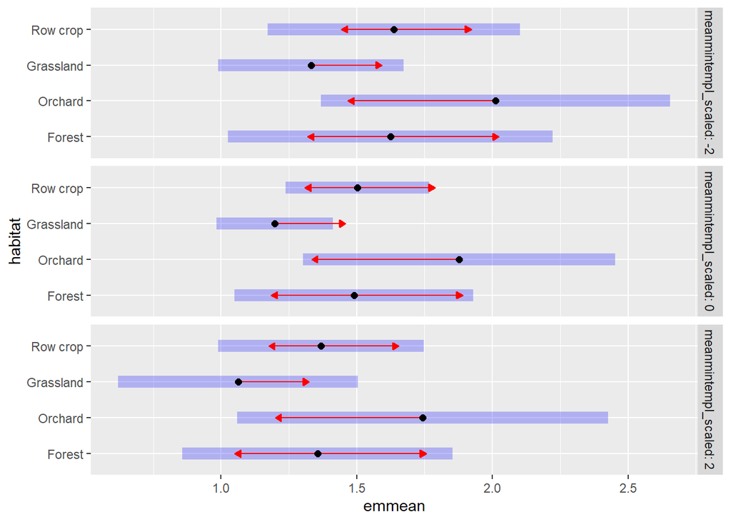

```r
emmeans(g_lintemp_addmin,specs = pairwise ~ habitat,by = c("meanmintempI_scaled"), at = list(meanmintempI_scaled = c(-2,0,2))) %>% plot(comparisons = TRUE)
```

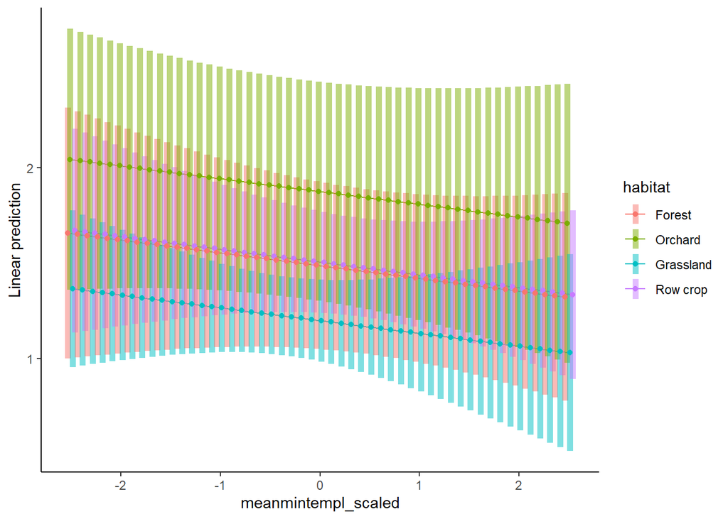

```r
emmip(g_lintemp_addmin,formula = habitat ~ meanmintempI_scaled, at = list(meanmintempI_scaled = seq(from = -2.5, to = 2.5, by = .1)),CIs = TRUE, plotit = FALSE) %>% emmip_ggplot() + theme_classic()
```

## Combined WEBL and TRES growth plots

```r
ggplot_build(fig2_webl)$layout$panel_scales_y
```

```
## [[1]]
## <ScaleContinuousPosition>
##  Range:  -1.09 -- 3.42
##  Limits: -1.09 -- 3.42
```

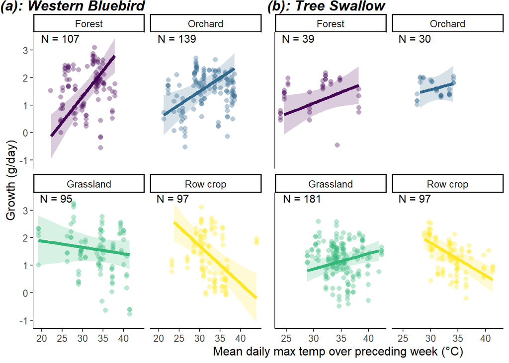

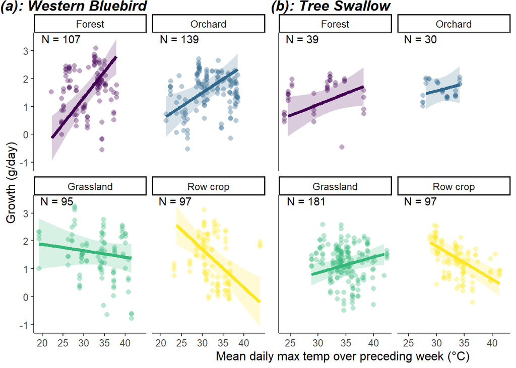

```r
(p_full <- ggarrange(fig2_webl + theme(text = element_text(size = 12),axis.title.x = element_blank()),fig2_tres + ylim(-1.09,3.42) + theme(axis.text.y = element_blank(),
                                        axis.ticks.y = element_blank(),
                                        text = element_text(size = 12),
                                        axis.title.y = element_blank(),
                                        axis.title.x = element_text(hjust = 2.8)),ncol = 2,
          labels = c("(a): Western Bluebird","(b): Tree Swallow")))
```

```r
ggsave("../figures/fig2_growth_by_temp_hab.png",p_full,width = 6.25,height = 4)
```

# Models to estimate the unbiased causal effect of cort and provisioning on growth

Model structure pulled from DAG: will use a minimal adjustment set to estimate the total effect of cort and provisioning on growth. { attempt, humidity, nest_age, nestcond, surftemp }

I could subtract the direct from the total effect to get the indirect effect. I’m still vacillating between thinking that I should be measuring the total effect or the direct effect. I think because nestcond is really the only mediator in the DAG that I actually want total effect?

The question I’d like to ask: Does the direct effect of these two factors on growth change depending on habitat? I’m not sure that this causal structure is the correct one for that question. Is that a mediation analysis? After reading some papers, I think that actually the question is, do cort and provisioning mediate the effect of habitat and temperature on growth? I still think there may be other questions in this dataset. Maybe the answer is to do this paper just linear modeling with causal inference support, and then get Sage in on a paper that delves more deeply into a structural causal modeling framework.

The following focuses on the more simple question: how do cort and provisioning affect growth (total effect)? I will do the same model structure for survival in that notebook.

adjustment set: { attempt, humidity, nest_age, nestcond, surftemp }

```r
g_provis_cort <- lmerTest::lmer(gweight ~ cort_s1_scaled + provis_mean_scaled + meanmaxtempI_scaled + meanmintempI_scaled + meanh_scaled + age_scaled + condition_scaled + (1|attempt_id),data = dplyr::filter(g,Species == "WEBL",!is.na(meanmaxtempI),meanmaxtempI < 45,!is.na(meanmintempI)) %>%
  mutate(across(c(gweight,meanmaxtempI,meanmintempI,juliandate,brood_size,age,meanh,cort_s1,condition,provis_mean),
                                                  ~ scale(.x)[,1],
                                                   .names = "{.col}_scaled"),
                                           meanmaxtempI_scaled_sq = meanmaxtempI_scaled * meanmaxtempI_scaled))


summary(g_provis_cort)
```

```
## Linear mixed model fit by REML. t-tests use Satterthwaite's method [
## lmerModLmerTest]
## Formula: gweight ~ cort_s1_scaled + provis_mean_scaled + meanmaxtempI_scaled +
##     meanmintempI_scaled + meanh_scaled + age_scaled + condition_scaled +
##     (1 | attempt_id)
##    Data:
## dplyr::filter(g, Species == "WEBL", !is.na(meanmaxtempI), meanmaxtempI <
##     45, !is.na(meanmintempI)) %>% mutate(across(c(gweight, meanmaxtempI,
##     meanmintempI, juliandate, brood_size, age, meanh, cort_s1,
##     condition, provis_mean), ~scale(.x)[, 1], .names = "{.col}_scaled"),
##     meanmaxtempI_scaled_sq = meanmaxtempI_scaled * meanmaxtempI_scaled)
##
## REML criterion at convergence: 56.5
##
## Scaled residuals:
##      Min       1Q   Median       3Q      Max
## -2.33012 -0.54219  0.04431  0.44610  1.67783
##
## Random effects:
##  Groups     Name        Variance Std.Dev.
##  attempt_id (Intercept) 0.03221  0.1795
##  Residual               0.14592  0.3820
## Number of obs: 40, groups:  attempt_id, 10
##
## Fixed effects:
##                     Estimate Std. Error       df t value Pr(>|t|)
## (Intercept)          1.81159    0.12684  5.42799  14.283 1.63e-05 ***
## cort_s1_scaled      -0.08897    0.07219 29.50573  -1.233  0.22748
## provis_mean_scaled   0.31736    0.09026  8.38237   3.516  0.00733 **
## meanmaxtempI_scaled -0.42790    0.16285 20.56232  -2.628  0.01591 *
## meanmintempI_scaled  0.08272    0.12200  3.78157   0.678  0.53694
## meanh_scaled        -0.48552    0.19323  8.78671  -2.513  0.03375 *
## age_scaled          -0.63324    0.10319 23.11722  -6.137 2.86e-06 ***
## condition_scaled     0.12034    0.18256 27.80827   0.659  0.51521
## ---
## Signif. codes:  0 '***' 0.001 '**' 0.01 '*' 0.05 '.' 0.1 ' ' 1
##
## Correlation of Fixed Effects:
##             (Intr) crt_1_ prvs__ mnmxI_ mnmnI_ mnh_sc ag_scl
## crt_s1_scld  0.035
## prvs_mn_scl  0.168 -0.014
## mnmxtmpI_sc -0.550 -0.031 -0.307
## mnmntmpI_sc -0.276  0.041  0.136 -0.278
## meanh_scald -0.629 -0.057 -0.443  0.811  0.007
## age_scaled   0.016 -0.376 -0.236  0.025 -0.417  0.020
## condtn_scld  0.077  0.222 -0.045 -0.019 -0.024 -0.109 -0.455
```

```r
(t <- summary(g_provis_cort) %>% coef() %>% as_tibble(rownames = "Covariate") %>%
   # dplyr::filter(Covariate != "poly(mean_temp_scaled, 2)1") %>%
   mutate(across(Estimate:`t value`,~round(.x,digits = 2)),
          across(`Pr(>|t|)`,~round(.x,digits = 3))) %>% gt())
```

| Covariate | Estimate | Std. Error | df | t value | Pr(>\|t\|) |
| --- | --- | --- | --- | --- | --- |
| (Intercept) | 1.81 | 0.13 | 5.43 | 14.28 | 0.000 |
| cort_s1_scaled | -0.09 | 0.07 | 29.51 | -1.23 | 0.227 |
| provis_mean_scaled | 0.32 | 0.09 | 8.38 | 3.52 | 0.007 |
| meanmaxtempI_scaled | -0.43 | 0.16 | 20.56 | -2.63 | 0.016 |
| meanmintempI_scaled | 0.08 | 0.12 | 3.78 | 0.68 | 0.537 |
| meanh_scaled | -0.49 | 0.19 | 8.79 | -2.51 | 0.034 |
| age_scaled | -0.63 | 0.10 | 23.12 | -6.14 | 0.000 |
| condition_scaled | 0.12 | 0.18 | 27.81 | 0.66 | 0.515 |

```r
gtsave(t,"../figures/growth_by_cort_provis_summary_webl.html")

data = dplyr::filter(g,Species == "WEBL",!is.na(gweight),!is.na(cort_s1),!is.na(provis_mean),!is.na(meanmaxtempI),
                     !is.na(meanmintempI),!is.na(meanh),!is.na(age),!is.na(condition)) %>%
  mutate(across(c(gweight,meanmaxtempI,meanmintempI,juliandate,brood_size,age,meanh,cort_s1,condition,provis_mean),
                                                  ~ scale(.x)[,1],
                                                   .names = "{.col}_scaled"),
                                           meanmaxtempI_scaled_sq = meanmaxtempI_scaled * meanmaxtempI_scaled)

(t <- emmeans(g_provis_cort,specs = ~ provis_mean_scaled,by = c("provis_mean_scaled"), at = list(provis_mean_scaled = c(-2,0,2)),type = "response") %>% as.tibble() %>% #gt() %>%
  mutate(provis_mean_scaled = (provis_mean_scaled * sd(data$provis_mean, na.rm = TRUE)) + mean(data$provis_mean,na.rm = TRUE),
    across(where(is.numeric), ~ round(.x, digits = 2)),
    provis_mean_scaled = round(provis_mean_scaled)) %>%
  #tibble() %>%
  dplyr::select(-df) %>%
  #mutate(Model = rep(c("TA2 * LU + TA * LU", "TA2 + TA * LU", "TA2 + TA + LU"),2), type = c(rep("minimum TA", 3),rep("Minimum TA",3)), .before = AIC) %>%
  rename(`Provisioning` = "provis_mean_scaled",`Predicted growth` = "emmean",`2.5%` = "lower.CL",`97.5%` = "upper.CL" ) %>%
    #mutate(`minimum TA_P` = if_else(`minimum TA_P` == 0.000,"<0.001",as.character(`minimum TA_P`))) %>%
  #mutate(`Minimum TA_P` = if_else(`Minimum TA_P` == 0.000,"<0.001",as.character(`Minimum TA_P`))) %>%
  gt() %>% tab_options(data_row.padding = px(1)))
```

| Provisioning | Predicted growth | SE | 2.5% | 97.5% |
| --- | --- | --- | --- | --- |
| 0 | 0.77 | 0.21 | 0.27 | 1.27 |
| 11 | 1.40 | 0.09 | 1.16 | 1.65 |
| 21 | 2.04 | 0.20 | 1.59 | 2.49 |

```r
gtsave(t,"../figures/growth_by_basecort_provis_delta_webl.html")

((emmeans(g_provis_cort,specs = ~ provis_mean_scaled,by = c("provis_mean_scaled"), at = list(provis_mean_scaled = c(2)),type = "response") %>% as.tibble() %>% pull(emmean))-(emmeans(g_provis_cort,specs = ~ provis_mean_scaled,by = c("provis_mean_scaled"), at = list(provis_mean_scaled = c(-2)),type = "response") %>% as.tibble() %>% pull(emmean)))/(emmeans(g_provis_cort,specs = ~ provis_mean_scaled,by = c("provis_mean_scaled"), at = list(provis_mean_scaled = c(-2)),type = "response") %>% as.tibble() %>% pull(emmean))
```

```
## [1] 1.64866
```

```r
g_provis_abscort <- lmerTest::lmer(gweight ~ abs_change_cort_scaled + provis_mean_scaled + meanmaxtempI_scaled + meanmintempI_scaled + meanh_scaled + age_scaled + condition_scaled + (1|attempt_id),data = dplyr::filter(g,Species == "WEBL",!is.na(meanmaxtempI),meanmaxtempI < 45,!is.na(meanmintempI)) %>%
  mutate(across(c(gweight,meanmaxtempI,meanmintempI,juliandate,brood_size,age,meanh,abs_change_cort,condition,provis_mean),
                                                  ~ scale(.x)[,1],
                                                   .names = "{.col}_scaled"),
                                           meanmaxtempI_scaled_sq = meanmaxtempI_scaled * meanmaxtempI_scaled))


summary(g_provis_abscort)
```

```
## Linear mixed model fit by REML. t-tests use Satterthwaite's method [
## lmerModLmerTest]
## Formula:
## gweight ~ abs_change_cort_scaled + provis_mean_scaled + meanmaxtempI_scaled +
##     meanmintempI_scaled + meanh_scaled + age_scaled + condition_scaled +
##     (1 | attempt_id)
##    Data:
## dplyr::filter(g, Species == "WEBL", !is.na(meanmaxtempI), meanmaxtempI <
##     45, !is.na(meanmintempI)) %>% mutate(across(c(gweight, meanmaxtempI,
##     meanmintempI, juliandate, brood_size, age, meanh, abs_change_cort,
##     condition, provis_mean), ~scale(.x)[, 1], .names = "{.col}_scaled"),
##     meanmaxtempI_scaled_sq = meanmaxtempI_scaled * meanmaxtempI_scaled)
##
## REML criterion at convergence: 52.5
##
## Scaled residuals:
##      Min       1Q   Median       3Q      Max
## -1.87887 -0.53171 -0.02071  0.29883  1.87844
##
## Random effects:
##  Groups     Name        Variance Std.Dev.
##  attempt_id (Intercept) 0.1395   0.3734
##  Residual               0.1390   0.3728
## Number of obs: 35, groups:  attempt_id, 10
##
## Fixed effects:
##                        Estimate Std. Error       df t value Pr(>|t|)
## (Intercept)             1.96885    0.20195  5.72652   9.749 8.86e-05 ***
## abs_change_cort_scaled  0.19444    0.12446 26.84865   1.562   0.1299
## provis_mean_scaled      0.21963    0.16300 13.05898   1.347   0.2007
## meanmaxtempI_scaled    -0.44436    0.19373 19.87886  -2.294   0.0328 *
## meanmintempI_scaled     0.05789    0.19618  4.20648   0.295   0.7819
## meanh_scaled           -0.43778    0.26901  9.01064  -1.627   0.1381
## age_scaled             -0.69421    0.11757 12.20575  -5.905 6.72e-05 ***
## condition_scaled        0.28890    0.23132 25.41816   1.249   0.2231
## ---
## Signif. codes:  0 '***' 0.001 '**' 0.01 '*' 0.05 '.' 0.1 ' ' 1
##
## Correlation of Fixed Effects:
##             (Intr) abs___ prvs__ mnmxI_ mnmnI_ mnh_sc ag_scl
## abs_chng_c_  0.239
## prvs_mn_scl -0.235 -0.356
## mnmxtmpI_sc -0.320  0.190 -0.108
## mnmntmpI_sc -0.399 -0.005  0.229 -0.299
## meanh_scald -0.388  0.282 -0.410  0.699  0.075
## age_scaled   0.239 -0.022 -0.440 -0.056 -0.531 -0.083
## condtn_scld  0.255  0.154 -0.383 -0.048 -0.081  0.048 -0.169
```

```r
(t <- summary(g_provis_abscort) %>% coef() %>% as_tibble(rownames = "Covariate") %>%
   # dplyr::filter(Covariate != "poly(mean_temp_scaled, 2)1") %>%
   mutate(across(Estimate:`t value`,~round(.x,digits = 2)),
          across(`Pr(>|t|)`,~round(.x,digits = 3))) %>% gt())
```

| Covariate | Estimate | Std. Error | df | t value | Pr(>\|t\|) |
| --- | --- | --- | --- | --- | --- |
| (Intercept) | 1.97 | 0.20 | 5.73 | 9.75 | 0.000 |
| abs_change_cort_scaled | 0.19 | 0.12 | 26.85 | 1.56 | 0.130 |
| provis_mean_scaled | 0.22 | 0.16 | 13.06 | 1.35 | 0.201 |
| meanmaxtempI_scaled | -0.44 | 0.19 | 19.88 | -2.29 | 0.033 |
| meanmintempI_scaled | 0.06 | 0.20 | 4.21 | 0.30 | 0.782 |
| meanh_scaled | -0.44 | 0.27 | 9.01 | -1.63 | 0.138 |
| age_scaled | -0.69 | 0.12 | 12.21 | -5.90 | 0.000 |
| condition_scaled | 0.29 | 0.23 | 25.42 | 1.25 | 0.223 |

```r
gtsave(t,"../figures/growth_by_abscort_provis_summary_webl.html")

data = dplyr::filter(g,Species == "WEBL",!is.na(gweight),!is.na(abs_change_cort),!is.na(provis_mean),!is.na(meanmaxtempI),
                     !is.na(meanmintempI),!is.na(meanh),!is.na(age),!is.na(condition)) %>%
  mutate(across(c(gweight,meanmaxtempI,meanmintempI,juliandate,brood_size,age,meanh,cort_s1,condition,provis_mean),
                                                  ~ scale(.x)[,1],
                                                   .names = "{.col}_scaled"),
                                           meanmaxtempI_scaled_sq = meanmaxtempI_scaled * meanmaxtempI_scaled)

(t <- emmeans(g_provis_abscort,specs = ~ provis_mean_scaled,by = c("provis_mean_scaled"), at = list(provis_mean_scaled = c(-2,0,2)),type = "response") %>% as.tibble() %>% #gt() %>%
  mutate(provis_mean_scaled = (provis_mean_scaled * sd(data$provis_mean,na.rm = TRUE)) + mean(data$provis_mean,na.rm = TRUE),
    across(where(is.numeric), ~ round(.x, digits = 2)),
    provis_mean_scaled = round(provis_mean_scaled)) %>%
  #tibble() %>%
  dplyr::select(-df) %>%
  #mutate(Model = rep(c("TA2 * LU + TA * LU", "TA2 + TA * LU", "TA2 + TA + LU"),2), type = c(rep("minimum TA", 3),rep("Minimum TA",3)), .before = AIC) %>%
  rename(`max temperature` = "provis_mean_scaled",`Predicted growth` = "emmean",`2.5%` = "lower.CL",`97.5%` = "upper.CL" ) %>%
    #mutate(`minimum TA_P` = if_else(`minimum TA_P` == 0.000,"<0.001",as.character(`minimum TA_P`))) %>%
  #mutate(`Minimum TA_P` = if_else(`Minimum TA_P` == 0.000,"<0.001",as.character(`Minimum TA_P`))) %>%
  gt() %>% tab_options(data_row.padding = px(1)))
```

| max temperature | Predicted growth | SE | 2.5% | 97.5% |
| --- | --- | --- | --- | --- |
| 2 | 1.04 | 0.40 | 0.19 | 1.90 |
| 12 | 1.48 | 0.15 | 1.10 | 1.87 |
| 21 | 1.92 | 0.33 | 1.18 | 2.66 |

```r
gtsave(t,"../figures/growth_by_abscort_provis_delta_webl.html")
```

#### Sample size

```r
data_webl = dplyr::filter(g,Species == "WEBL",!is.na(gweight),!is.na(cort_s1),!is.na(provis_mean),!is.na(meanmaxtempI),
                     !is.na(meanmintempI),!is.na(meanh),!is.na(age),!is.na(condition)) %>%
  mutate(across(c(gweight,meanmaxtempI,meanmintempI,juliandate,brood_size,age,meanh,cort_s1,condition,provis_mean),
                                                  ~ scale(.x)[,1],
                                                   .names = "{.col}_scaled"),
                                           meanmaxtempI_scaled_sq = meanmaxtempI_scaled * meanmaxtempI_scaled)
samp_webl <- data_webl %>%
  group_by(habitat,year_fct) %>% summarize(count = n()) %>% pivot_wider(values_from = count,names_from = year_fct) %>% as.tibble() %>% rename(Habitat = 'habitat') %>%
  # relocate(`2021`,.before = `2022`) %>%
  ungroup() %>%
  mutate(across(c(`2022`,`2023`),~ replace_na(.x,0)),
         Total = `2022`+`2023`)
samp_webl %>% gt() %>%
  grand_summary_rows(columns = -c(Habitat),fns = list(id = "Total") ~ sum(.,na.rm = TRUE)) %>%
  gtsave("../figures/ss_year_webl_growthbybasecortprovis.html")
data = dplyr::filter(g,Species == "WEBL",!is.na(gweight),!is.na(abs_change_cort),!is.na(provis_mean),!is.na(meanmaxtempI),
                     !is.na(meanmintempI),!is.na(meanh),!is.na(age),!is.na(condition)) %>%
  mutate(across(c(gweight,meanmaxtempI,meanmintempI,juliandate,brood_size,age,meanh,cort_s1,condition,provis_mean),
                                                  ~ scale(.x)[,1],
                                                   .names = "{.col}_scaled"),
                                           meanmaxtempI_scaled_sq = meanmaxtempI_scaled * meanmaxtempI_scaled)
samp <- data %>%
  group_by(habitat,year_fct) %>% summarize(count = n()) %>% pivot_wider(values_from = count,names_from = year_fct) %>% as.tibble() %>% rename(Habitat = 'habitat') %>%
  # relocate(`2021`,.before = `2022`) %>%
  ungroup() %>%
  mutate(across(c(`2022`,`2023`),~ replace_na(.x,0)),
         Total = `2022`+`2023`)
samp %>% gt() %>%
  grand_summary_rows(columns = -c(Habitat),fns = list(id = "Total") ~ sum(.,na.rm = TRUE)) %>%
  gtsave("../figures/ss_year_webl_growthbyabscortprovis.html")
```

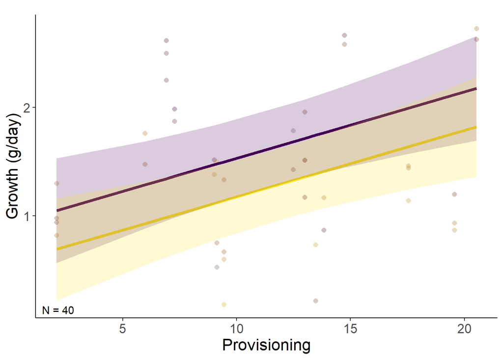

```r
mean_provis_webl <- mean(data_webl %>% pull(provis_mean))
sd_provis_webl <- sd(data_webl %>% pull(provis_mean))


provis_trans_webl <- trans_new("provis_trans_webl",
                          transform = function(x){(x * sd_provis_webl) + mean_provis_webl},
                          inverse = function(x){x})

(fig6_webl <- predict_response(g_provis_cort,terms = c("provis_mean_scaled","cort_s1_scaled [-2,2]"),bias_correction = TRUE,margin = "empirical") %>%
   plot(line_size = 1.5,alpha = .2,show_data = TRUE,limit_range = TRUE,colors = "viridis") +
    theme_classic() +
   #facet_wrap(~ group, ncol = 2) +
    xlab("Provisioning") +
    ylab("Growth (g/day)") +
   #scale_fill_viridis(discrete = TRUE) +
    #scale_color_viridis(discrete = TRUE) +
    theme(text = element_text(size = 16)) +
    labs(title = element_blank())  +
    scale_x_continuous(trans = provis_trans_webl,
                       breaks = c((0-mean_provis_webl)/sd_provis_webl,
                                  (5-mean_provis_webl)/sd_provis_webl,
                                  (10-mean_provis_webl)/sd_provis_webl,
                                  (15-mean_provis_webl)/sd_provis_webl,
                                  (20-mean_provis_webl)/sd_provis_webl)
    ) +
   #ylim(-5,5) +
   # geom_text(data = dat_text, mapping = aes(x = -Inf, y = Inf,label = label),hjust = -.2, vjust = 1.2,inherit.aes = FALSE) # +
    theme(legend.position = "none") +
    annotate(geom = "text",label = "N = 40",x = -Inf,y = -Inf,hjust = -.2,vjust = -.5)
   )
```

```r
ggsave("../figures/growthbycort+provis_WEBL.png",plot =  fig6_webl, width = 10, height = 6.6)
```

## Canonical adjustment set overloads the data:

{ attempt, broodsize, habitat, humidity, jul_date, mother_s1, nest_age, site, surftemp, year }

## TRES

```r
g_provis_cort <- lmerTest::lmer(gweight ~ cort_s1_scaled + provis_mean_scaled + meanmaxtempI_scaled + meanmintempI_scaled + meanh_scaled + age_scaled + condition_scaled + (1|attempt_id),data = dplyr::filter(g,Species == "TRES",!is.na(meanmaxtempI),!is.na(meanmintempI)) %>%
  mutate(across(c(gweight,meanmaxtempI,meanmintempI,juliandate,brood_size,age,meanh,cort_s1,condition,provis_mean),
                                                  ~ scale(.x)[,1],
                                                   .names = "{.col}_scaled"),
                                           meanmaxtempI_scaled_sq = meanmaxtempI_scaled * meanmaxtempI_scaled))
summary(g_provis_cort)
```

```
## Linear mixed model fit by REML. t-tests use Satterthwaite's method [
## lmerModLmerTest]
## Formula: gweight ~ cort_s1_scaled + provis_mean_scaled + meanmaxtempI_scaled +
##     meanmintempI_scaled + meanh_scaled + age_scaled + condition_scaled +
##     (1 | attempt_id)
##    Data:
## dplyr::filter(g, Species == "TRES", !is.na(meanmaxtempI), !is.na(meanmintempI)) %>%
##     mutate(across(c(gweight, meanmaxtempI, meanmintempI, juliandate,
##         brood_size, age, meanh, cort_s1, condition, provis_mean),
##         ~scale(.x)[, 1], .names = "{.col}_scaled"), meanmaxtempI_scaled_sq = meanmaxtempI_scaled *
##         meanmaxtempI_scaled)
##
## REML criterion at convergence: 8.6
##
## Scaled residuals:
##     Min      1Q  Median      3Q     Max
## -1.5486 -0.2913 -0.1274  0.2126  1.3647
##
## Random effects:
##  Groups     Name        Variance Std.Dev.
##  attempt_id (Intercept) 0.10514  0.3243
##  Residual               0.03274  0.1809
## Number of obs: 16, groups:  attempt_id, 7
##
## Fixed effects:
##                      Estimate Std. Error        df t value Pr(>|t|)
## (Intercept)          0.926801   0.944847  1.017553   0.981   0.5039
## cort_s1_scaled       0.184250   0.077100  7.202570   2.390   0.0472 *
## provis_mean_scaled  -0.143179   0.135097  0.801431  -1.060   0.5136
## meanmaxtempI_scaled  0.220042   0.538055  1.138951   0.409   0.7461
## meanmintempI_scaled  0.398552   0.939548  0.978506   0.424   0.7458
## meanh_scaled         0.941682   0.707886  0.959274   1.330   0.4172
## age_scaled          -0.170441   0.320144  0.863267  -0.532   0.6994
## condition_scaled    -0.003887   0.135470  7.862901  -0.029   0.9778
## ---
## Signif. codes:  0 '***' 0.001 '**' 0.01 '*' 0.05 '.' 0.1 ' ' 1
##
## Correlation of Fixed Effects:
##             (Intr) crt_1_ prvs__ mnmxI_ mnmnI_ mnh_sc ag_scl
## crt_s1_scld -0.396
## prvs_mn_scl  0.293 -0.238
## mnmxtmpI_sc -0.899  0.398 -0.375
## mnmntmpI_sc -0.969  0.401 -0.245  0.869
## meanh_scald -0.932  0.382 -0.333  0.912  0.876
## age_scaled   0.684 -0.234  0.097 -0.773 -0.749 -0.649
## condtn_scld -0.168 -0.163 -0.168  0.156  0.131  0.025 -0.176
```

```r
(t <- summary(g_provis_cort) %>% coef() %>% as_tibble(rownames = "Covariate") %>%
   # dplyr::filter(Covariate != "poly(mean_temp_scaled, 2)1") %>%
   mutate(across(Estimate:`t value`,~round(.x,digits = 2)),
          across(`Pr(>|t|)`,~round(.x,digits = 3))) %>% gt())
```

| Covariate | Estimate | Std. Error | df | t value | Pr(>\|t\|) |
| --- | --- | --- | --- | --- | --- |
| (Intercept) | 0.93 | 0.94 | 1.02 | 0.98 | 0.504 |
| cort_s1_scaled | 0.18 | 0.08 | 7.20 | 2.39 | 0.047 |
| provis_mean_scaled | -0.14 | 0.14 | 0.80 | -1.06 | 0.514 |
| meanmaxtempI_scaled | 0.22 | 0.54 | 1.14 | 0.41 | 0.746 |
| meanmintempI_scaled | 0.40 | 0.94 | 0.98 | 0.42 | 0.746 |
| meanh_scaled | 0.94 | 0.71 | 0.96 | 1.33 | 0.417 |
| age_scaled | -0.17 | 0.32 | 0.86 | -0.53 | 0.699 |
| condition_scaled | 0.00 | 0.14 | 7.86 | -0.03 | 0.978 |

```r
gtsave(t,"../figures/growth_by_cort_provis_summary_tres.html")

data = dplyr::filter(g,Species == "TRES",!is.na(gweight),!is.na(cort_s1),!is.na(provis_mean),!is.na(meanmaxtempI),
                     !is.na(meanmintempI),!is.na(meanh),!is.na(age),!is.na(condition)) %>%
  mutate(across(c(gweight,meanmaxtempI,meanmintempI,juliandate,brood_size,age,meanh,cort_s1,condition,provis_mean),
                                                  ~ scale(.x)[,1],
                                                   .names = "{.col}_scaled"),
                                           meanmaxtempI_scaled_sq = meanmaxtempI_scaled * meanmaxtempI_scaled)

(t <- emmeans(g_provis_cort,specs = ~ cort_s1_scaled,by = c("cort_s1_scaled"), at = list(cort_s1_scaled = c(-2,0,2)),type = "response") %>% as.tibble() %>% #gt() %>%
  mutate(cort_s1_scaled = (cort_s1_scaled * sd(data$cort_s1, na.rm = TRUE)) + mean(data$cort_s1,na.rm = TRUE),
    across(where(is.numeric), ~ round(.x, digits = 2)),
    cort_s1_scaled = round(cort_s1_scaled)) %>%
  #tibble() %>%
  dplyr::select(-df) %>%
  #mutate(Model = rep(c("TA2 * LU + TA * LU", "TA2 + TA * LU", "TA2 + TA + LU"),2), type = c(rep("minimum TA", 3),rep("Minimum TA",3)), .before = AIC) %>%
  rename(`Baseline cort` = "cort_s1_scaled",`Predicted growth` = "emmean",`2.5%` = "lower.CL",`97.5%` = "upper.CL" ) %>%
    #mutate(`minimum TA_P` = if_else(`minimum TA_P` == 0.000,"<0.001",as.character(`minimum TA_P`))) %>%
  #mutate(`Minimum TA_P` = if_else(`Minimum TA_P` == 0.000,"<0.001",as.character(`Minimum TA_P`))) %>%
  gt() %>% tab_options(data_row.padding = px(1)))
```

| Baseline cort | Predicted growth | SE | 2.5% | 97.5% |
| --- | --- | --- | --- | --- |
| 0 | 1.25 | 0.24 | 0.53 | 1.96 |
| 7 | 1.61 | 0.15 | -4.92 | 8.14 |
| 14 | 1.98 | 0.20 | 1.07 | 2.90 |

```r
gtsave(t,"../figures/growth_by_basecort_provis_delta_tres.html")

((emmeans(g_provis_cort,specs = ~ cort_s1_scaled,by = c("cort_s1_scaled"), at = list(cort_s1_scaled = c(2)),type = "response") %>% as.tibble() %>% pull(emmean))-(emmeans(g_provis_cort,specs = ~ cort_s1_scaled,by = c("cort_s1_scaled"), at = list(cort_s1_scaled = c(-2)),type = "response") %>% as.tibble() %>% pull(emmean)))/(emmeans(g_provis_cort,specs = ~ cort_s1_scaled,by = c("cort_s1_scaled"), at = list(cort_s1_scaled = c(-2)),type = "response") %>% as.tibble() %>% pull(emmean))
```

```
## [1] 0.5915938
```

#### Abs diff cort

```r
g_provis_abscort <- lmerTest::lmer(gweight ~ abs_change_cort_scaled + provis_mean_scaled + meanmaxtempI_scaled + meanmintempI_scaled + meanh_scaled + age_scaled + condition_scaled + (1|attempt_id),data = dplyr::filter(g,Species == "TRES",!is.na(meanmaxtempI),!is.na(meanmintempI)) %>%
  mutate(across(c(gweight,meanmaxtempI,meanmintempI,juliandate,brood_size,age,meanh,abs_change_cort,condition,provis_mean),
                                                  ~ scale(.x)[,1],
                                                   .names = "{.col}_scaled"),
                                           meanmaxtempI_scaled_sq = meanmaxtempI_scaled * meanmaxtempI_scaled))
summary(g_provis_cort)
```

```
## Linear mixed model fit by REML. t-tests use Satterthwaite's method [
## lmerModLmerTest]
## Formula: gweight ~ cort_s1_scaled + provis_mean_scaled + meanmaxtempI_scaled +
##     meanmintempI_scaled + meanh_scaled + age_scaled + condition_scaled +
##     (1 | attempt_id)
##    Data:
## dplyr::filter(g, Species == "TRES", !is.na(meanmaxtempI), !is.na(meanmintempI)) %>%
##     mutate(across(c(gweight, meanmaxtempI, meanmintempI, juliandate,
##         brood_size, age, meanh, cort_s1, condition, provis_mean),
##         ~scale(.x)[, 1], .names = "{.col}_scaled"), meanmaxtempI_scaled_sq = meanmaxtempI_scaled *
##         meanmaxtempI_scaled)
##
## REML criterion at convergence: 8.6
##
## Scaled residuals:
##     Min      1Q  Median      3Q     Max
## -1.5486 -0.2913 -0.1274  0.2126  1.3647
##
## Random effects:
##  Groups     Name        Variance Std.Dev.
##  attempt_id (Intercept) 0.10514  0.3243
##  Residual               0.03274  0.1809
## Number of obs: 16, groups:  attempt_id, 7
##
## Fixed effects:
##                      Estimate Std. Error        df t value Pr(>|t|)
## (Intercept)          0.926801   0.944847  1.017553   0.981   0.5039
## cort_s1_scaled       0.184250   0.077100  7.202570   2.390   0.0472 *
## provis_mean_scaled  -0.143179   0.135097  0.801431  -1.060   0.5136
## meanmaxtempI_scaled  0.220042   0.538055  1.138951   0.409   0.7461
## meanmintempI_scaled  0.398552   0.939548  0.978506   0.424   0.7458
## meanh_scaled         0.941682   0.707886  0.959274   1.330   0.4172
## age_scaled          -0.170441   0.320144  0.863267  -0.532   0.6994
## condition_scaled    -0.003887   0.135470  7.862901  -0.029   0.9778
## ---
## Signif. codes:  0 '***' 0.001 '**' 0.01 '*' 0.05 '.' 0.1 ' ' 1
##
## Correlation of Fixed Effects:
##             (Intr) crt_1_ prvs__ mnmxI_ mnmnI_ mnh_sc ag_scl
## crt_s1_scld -0.396
## prvs_mn_scl  0.293 -0.238
## mnmxtmpI_sc -0.899  0.398 -0.375
## mnmntmpI_sc -0.969  0.401 -0.245  0.869
## meanh_scald -0.932  0.382 -0.333  0.912  0.876
## age_scaled   0.684 -0.234  0.097 -0.773 -0.749 -0.649
## condtn_scld -0.168 -0.163 -0.168  0.156  0.131  0.025 -0.176
```

```r
(t <- summary(g_provis_abscort) %>% coef() %>% as_tibble(rownames = "Covariate") %>%
   # dplyr::filter(Covariate != "poly(mean_temp_scaled, 2)1") %>%
   mutate(across(Estimate:`t value`,~round(.x,digits = 2)),
          across(`Pr(>|t|)`,~round(.x,digits = 3))) %>% gt())
```

| Covariate | Estimate | Std. Error | df | t value | Pr(>\|t\|) |
| --- | --- | --- | --- | --- | --- |
| (Intercept) | 1.98 | 0.54 | 6 | 3.67 | 0.011 |
| abs_change_cort_scaled | 0.04 | 0.11 | 6 | 0.38 | 0.720 |
| provis_mean_scaled | -0.06 | 0.11 | 6 | -0.56 | 0.594 |
| meanmaxtempI_scaled | -0.38 | 0.35 | 6 | -1.09 | 0.319 |
| meanmintempI_scaled | -0.59 | 0.50 | 6 | -1.17 | 0.286 |
| meanh_scaled | 0.25 | 0.39 | 6 | 0.65 | 0.542 |
| age_scaled | 0.02 | 0.20 | 6 | 0.09 | 0.933 |
| condition_scaled | -0.06 | 0.23 | 6 | -0.25 | 0.812 |

```r
gtsave(t,"../figures/growth_by_cort_provis_summary_tres.html")

data = dplyr::filter(g,Species == "TRES",!is.na(gweight),!is.na(abs_change_cort),!is.na(provis_mean),!is.na(meanmaxtempI),
                     !is.na(meanmintempI),!is.na(meanh),!is.na(age),!is.na(condition)) %>%
  mutate(across(c(gweight,meanmaxtempI,meanmintempI,juliandate,brood_size,age,meanh,abs_change_cort,condition,provis_mean),
                                                  ~ scale(.x)[,1],
                                                   .names = "{.col}_scaled"),
                                           meanmaxtempI_scaled_sq = meanmaxtempI_scaled * meanmaxtempI_scaled)

(t <- emmeans(g_provis_abscort,specs = ~ abs_change_cort_scaled,by = c("abs_change_cort_scaled"), at = list(abs_change_cort_scaled = c(-2,0,2)),type = "response") %>% as.tibble() %>% #gt() %>%
  mutate(abs_change_cort_scaled = (abs_change_cort_scaled * sd(data$abs_change_cort, na.rm = TRUE)) + mean(data$abs_change_cort,na.rm = TRUE),
    across(where(is.numeric), ~ round(.x, digits = 2)),
    abs_change_cort_scaled = round(abs_change_cort_scaled)) %>%
  #tibble() %>%
  dplyr::select(-df) %>%
  #mutate(Model = rep(c("TA2 * LU + TA * LU", "TA2 + TA * LU", "TA2 + TA + LU"),2), type = c(rep("minimum TA", 3),rep("Minimum TA",3)), .before = AIC) %>%
  rename(`Baseline cort` = "abs_change_cort_scaled",`Predicted growth` = "emmean",`2.5%` = "lower.CL",`97.5%` = "upper.CL" ) %>%
    #mutate(`minimum TA_P` = if_else(`minimum TA_P` == 0.000,"<0.001",as.character(`minimum TA_P`))) %>%
  #mutate(`Minimum TA_P` = if_else(`Minimum TA_P` == 0.000,"<0.001",as.character(`Minimum TA_P`))) %>%
  gt() %>% tab_options(data_row.padding = px(1)))
```

| Baseline cort | Predicted growth | SE | 2.5% | 97.5% |
| --- | --- | --- | --- | --- |
| -12 | 1.64 | 0.29 | 7.000000e-02 | 3.210000e+00 |
| 38 | 1.72 | 0.08 | -2.807208e+73 | 2.807208e+73 |
| 88 | 1.81 | 0.30 | -2.350000e+00 | 5.960000e+00 |

```r
gtsave(t,"../figures/growth_by_basecort_provis_delta_tres.html")

((emmeans(g_provis_abscort,specs = ~ abs_change_cort_scaled,by = c("abs_change_cort_scaled"), at = list(abs_change_cort_scaled = c(2)),type = "response") %>% as.tibble() %>% pull(emmean))-(emmeans(g_provis_abscort,specs = ~ abs_change_cort_scaled,by = c("abs_change_cort_scaled"), at = list(abs_change_cort_scaled = c(-2)),type = "response") %>% as.tibble() %>% pull(emmean)))/(emmeans(g_provis_abscort,specs = ~ abs_change_cort_scaled,by = c("abs_change_cort_scaled"), at = list(abs_change_cort_scaled = c(-2)),type = "response") %>% as.tibble() %>% pull(emmean))
```

```
## [1] 0.09995707
```

#### Sample size

```r
data_tres = dplyr::filter(g,Species == "TRES",!is.na(gweight),!is.na(cort_s1),!is.na(provis_mean),!is.na(meanmaxtempI),
                     !is.na(meanmintempI),!is.na(meanh),!is.na(age),!is.na(condition)) %>%
  mutate(across(c(gweight,meanmaxtempI,meanmintempI,juliandate,brood_size,age,meanh,cort_s1,condition,provis_mean),
                                                  ~ scale(.x)[,1],
                                                   .names = "{.col}_scaled"),
                                           meanmaxtempI_scaled_sq = meanmaxtempI_scaled * meanmaxtempI_scaled)
samp_tres <- data_tres %>%
  group_by(habitat,year_fct) %>% summarize(count = n()) %>% pivot_wider(values_from = count,names_from = year_fct) %>% as.tibble() %>% rename(Habitat = 'habitat') %>%
  # relocate(`2021`,.before = `2022`) %>%
  ungroup() %>%
  mutate(across(c(`2022`,`2023`),~ replace_na(.x,0)),
         Total = `2022`+`2023`)
samp_tres %>% gt() %>%
  grand_summary_rows(columns = -c(Habitat),fns = list(id = "Total") ~ sum(.,na.rm = TRUE)) %>%
  gtsave("../figures/ss_year_TRES_growthbybasecortprovis.html")
data = dplyr::filter(g,Species == "TRES",!is.na(gweight),!is.na(abs_change_cort),!is.na(provis_mean),!is.na(meanmaxtempI),
                     !is.na(meanmintempI),!is.na(meanh),!is.na(age),!is.na(condition)) %>%
  mutate(across(c(gweight,meanmaxtempI,meanmintempI,juliandate,brood_size,age,meanh,cort_s1,condition,provis_mean),
                                                  ~ scale(.x)[,1],
                                                   .names = "{.col}_scaled"),
                                           meanmaxtempI_scaled_sq = meanmaxtempI_scaled * meanmaxtempI_scaled)
samp <- data %>%
  group_by(habitat,year_fct) %>% summarize(count = n()) %>% pivot_wider(values_from = count,names_from = year_fct) %>% as.tibble() %>% rename(Habitat = 'habitat') %>%
  # relocate(`2021`,.before = `2022`) %>%
  ungroup() %>%
  mutate(across(c(`2022`,`2023`),~ replace_na(.x,0)),
         Total = `2022`+`2023`)
samp %>% gt() %>%
  grand_summary_rows(columns = -c(Habitat),fns = list(id = "Total") ~ sum(.,na.rm = TRUE)) %>%
  gtsave("../figures/ss_year_TRES_growthbyabscortprovis.html")
```

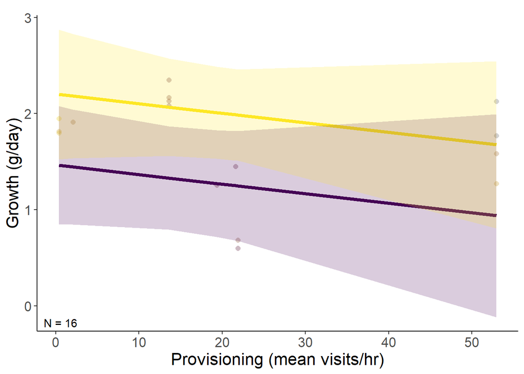

```r
mean_provis_tres <- mean(data_tres %>% pull(provis_mean))
sd_provis_tres <- sd(data_tres %>% pull(provis_mean))


provis_trans_tres <- trans_new("provis_trans_tres",
                          transform = function(x){(x * sd_provis_tres) + mean_provis_tres},
                          inverse = function(x){x})

(fig6_tres <- predict_response(g_provis_cort,terms = c("provis_mean_scaled","cort_s1_scaled [-2,2]"),bias_correction = TRUE) %>%
   #filter(group != 0.35) %>%
    # mutate(group = as_factor(group) %>% fct_collapse(Low = "-0.93",High = "1.63")) %>%
   plot(line_size = 1.5,alpha = .2,show_data = TRUE,limit_range = TRUE,colors = "viridis") +
   #scale_fill_discrete(labels = c("Low","High")) +
   #scale_color_discrete(labels = c("Low","High")) +
   # geom_point(show.legend = FALSE) +
    theme_classic() +
   #facet_wrap(~ group, ncol = 2) +
    xlab("Provisioning (mean visits/hr)") +
    ylab("Growth (g/day)") +
   #scale_fill_viridis(discrete = TRUE) +
    #scale_color_viridis(discrete = TRUE) +
    theme(text = element_text(size = 16)) +
    labs(title = element_blank(),color = "Baseline cort") +
    scale_x_continuous(trans = provis_trans_tres,
                       breaks = c((0-mean_provis_tres)/sd_provis_tres,
                                  (10-mean_provis_tres)/sd_provis_tres,
                                  (20-mean_provis_tres)/sd_provis_tres,
                                  (30-mean_provis_tres)/sd_provis_tres,
                                  (40-mean_provis_tres)/sd_provis_tres,
                                  (50-mean_provis_tres)/sd_provis_tres)
    ) +
   #ylim(-5,5) #+
   # geom_text(data = dat_text, mapping = aes(x = -Inf, y = Inf,label = label),hjust = -.2, vjust = 1.2,inherit.aes = FALSE) # +
  theme(legend.position = "none") +
    annotate("text",x = -Inf,y = -Inf,hjust = -.2,vjust = -.5,label = "N = 16")
   )
```

```r
ggsave("../figures/growthbycort+provis_TRES.png",plot =  fig6_tres, width = 10, height = 6.6)
```

## Combined WEBL and TRES growth plots

```r
ggplot_build(fig6_webl)$layout$panel_scales_y
```

```
## [[1]]
## <ScaleContinuousPosition>
##  Range:  0.183 -- 2.73
##  Limits: 0.183 -- 2.73
```

```r
ggplot_build(fig6_tres)$layout$panel_scales_y
```

```
## [[1]]
## <ScaleContinuousPosition>
##  Range:  -0.115 -- 2.87
##  Limits: -0.115 -- 2.87
```

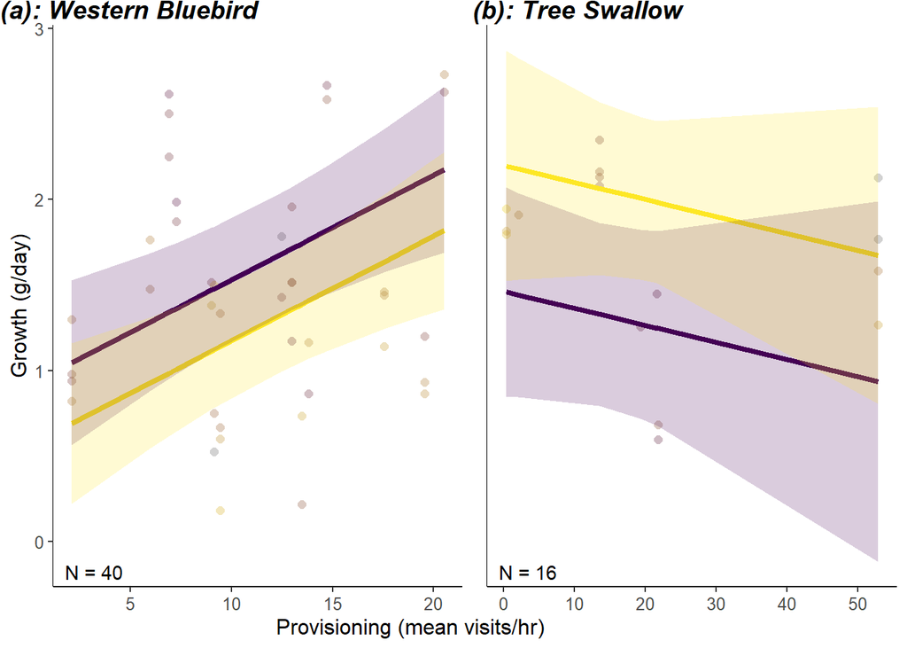

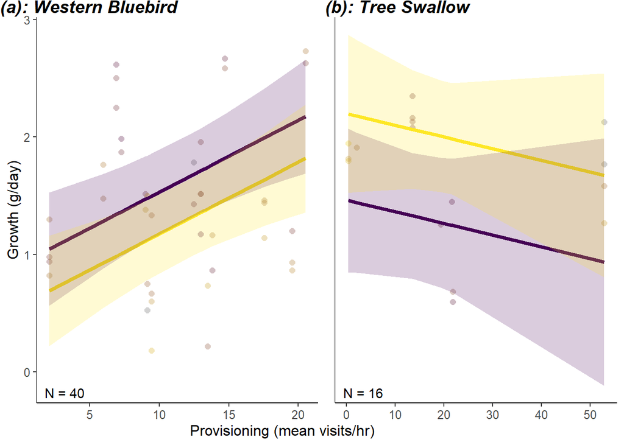

```r
(p_full <- ggarrange(fig6_webl + theme(text = element_text(size = 12),legend.position = "none",axis.title.x = element_blank()) + ylim(-.115,2.87),fig6_tres + theme(axis.text.y = element_blank(),
                                        axis.ticks.y = element_blank(),
                                        text = element_text(size = 12),
                                        axis.title.y = element_blank(),
                                        legend.position = 'none',
                                        axis.title.x = element_text(hjust = -1.5)),ncol = 2,
          labels = c("(a): Western Bluebird","(b): Tree Swallow")))
```

```r
ggsave("../figures/fig6_growth_by_temp_hab.png",p_full,width = 6.25,height = 4)
```